# Exploring the Relationship Between Religious Fundamentalism and Homophobia as mediated by class, gender, and education level

- Show All Code
- Hide All Code
- View Source

Author

Erin Readling

Published

March 27, 2024

## Variables of Interest

- **spkhomo** - Should an individual who declares himself a homosexual be allowed to speak in public (1=yes, 2=no)
- **coninc** - Household income (Since this variable is based on categorical data, income is not continuous but based on categorical mid-points and imputations. I=Not Applicable)
- **degree**- Degrees held by respondent (0=less than high school,1=high school,2=associates/junior college, 3=bachelors, 4=graduate)
- **sexnow1**- Sex of Respondent (1=male, 2=female, 3=transgender, 4=non of these)
- **fund**- Fundamentalism/liberalism of respondents religion (1=fundamentalist, 2=moderate, 3=liberal)

```r
#load in project data
load("/Volumes/courses/QAC/qac201/Studies and Codebooks/GSS/Data/gss_2021.RData")

#create subset of relevant variables
var.to.keep<-c("spkhomo","coninc","degree","sexnow1","fund")
SUBDATA<-gss2021[,var.to.keep]

#load in necessary libraries
library(ggplot2)
library(descr)
install.packages("wesanderson",repos = "http://cran.us.r-project.org")
library(wesanderson)
```

## Data Management

First I made new variables with string identifiers instead of ordinal data. I then made highest degree an ordered factor and turned income into a variable with 4 groups according to the median and standard deviation (<Q1, Q1-Median, Median-Q2, Q2>). I also made a new dataset **data_no_NA** that excluded all respondents who did not answer the key questions of interest.

```r
# Make a new variable called homophobia and set it to "yes" if someone is homophobic and "no" if they are not
SUBDATA$homophobia[SUBDATA$spkhomo == 1] <-"No"
SUBDATA$homophobia[SUBDATA$spkhomo == 2] <-"Yes"

# Make a new variable which shows female or male for sex
SUBDATA$sex1[SUBDATA$sexnow1 == 1] <-"Male"
SUBDATA$sex1[SUBDATA$sexnow1 == 2] <-"Female"
SUBDATA$sex1[SUBDATA$sexnow1 == 3] <-"Transgender"
SUBDATA$sex1[SUBDATA$sexnow1 == 4] <-"None of these"

# Make new variable with descriptions of highest degree i.e. "less than high school"
SUBDATA$highestdegree[SUBDATA$degree==0]<-"< high school"
SUBDATA$highestdegree[SUBDATA$degree==1]<-"high school"
SUBDATA$highestdegree[SUBDATA$degree==2]<-"associates"
SUBDATA$highestdegree[SUBDATA$degree==3]<-"bachelors"
SUBDATA$highestdegree[SUBDATA$degree==4]<-"graduate"

#make highest degree an ordered factor
SUBDATA$highestdegree<-factor(SUBDATA$highestdegree, levels=c("< high school","high school", "associates", "bachelors", "graduate"),ordered=TRUE)

#make a new variable with descriptions of fundamentalist level.
SUBDATA$fundamentalistlvl[SUBDATA$fund==1]<-"fundamentalist"
SUBDATA$fundamentalistlvl[SUBDATA$fund==2]<-"moderate"
SUBDATA$fundamentalistlvl[SUBDATA$fund==3]<-"liberal"

#make a new variable which makes income a categorical variable (0-Q1, Q1-Median, Median-Q2, >Q2)
SUBDATA$income[SUBDATA$coninc<=21840]<- "< $21,840"
SUBDATA$income[SUBDATA$coninc<=45360 & SUBDATA$coninc >21840]<- "$21,840 - $45,360"
SUBDATA$income[SUBDATA$coninc<=67200 & SUBDATA$coninc > 45360]<- "$45,360 - $67,200"
SUBDATA$income[SUBDATA$coninc>67200]<- "> $67,200"

#make income an ordered factor
SUBDATA$income<-factor(SUBDATA$income, levels=c("< $21,840","$21,840 - $45,360","$45,360 - $67,200","> $67,200"),ordered=TRUE)

#make fundamentalistlvl an ordered factor
SUBDATA$fundamentalistlvl<-factor(SUBDATA$fundamentalistlvl, levels=c("fundamentalist","moderate","liberal"),ordered=TRUE)

#make a new variable called homo and set it equal to 1 if someone is homophobic and 0 if they are not.
SUBDATA$homo[SUBDATA$spkhomo == 1] <-0
SUBDATA$homo[SUBDATA$spkhomo == 2] <-1

#flag responses with missing values for fundamentalism and homopohobia
MISSING <- is.na(SUBDATA$homo) |
  is.na(SUBDATA$fundamentalistlvl) |
  is.na(SUBDATA$sex1) |
  is.na(SUBDATA$highestdegree)|
  is.na(SUBDATA$coninc)

#count # rows marked for deletion
#sum(MISSING)

#create new database with only complete responses
data_no_NA <- subset(SUBDATA, subset = !MISSING)
```

## Data Visualizations

Exploring the distribution of key variables within the dataset.

### Univariate Graphs

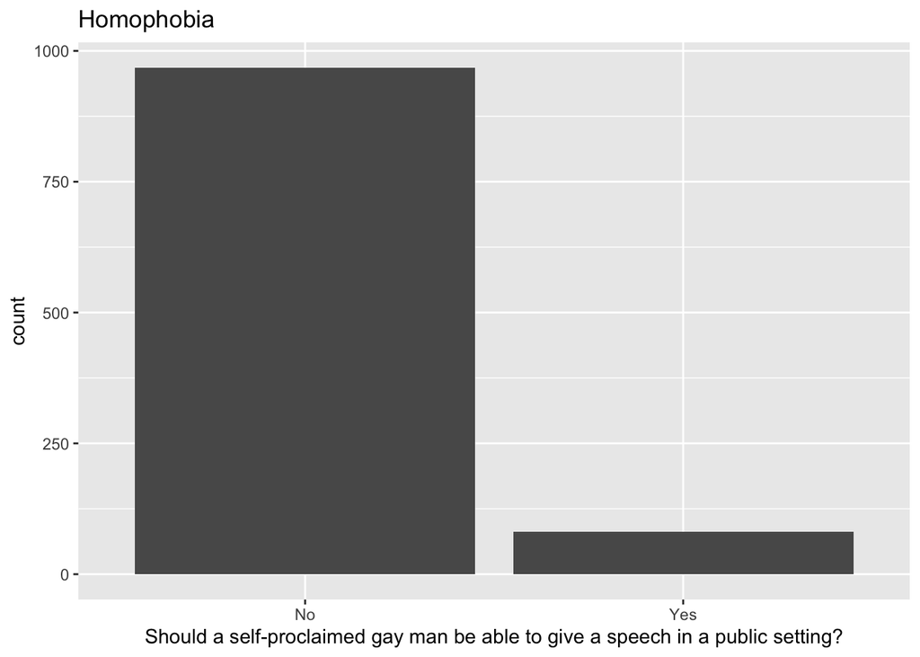

```r
#graphing homophobia in the sample
ggplot(data=data_no_NA)+
   geom_bar(aes(x=homophobia))+
   ggtitle("Homophobia")+
   xlab("Should a self-proclaimed gay man be able to give a speech in a public setting?")
```

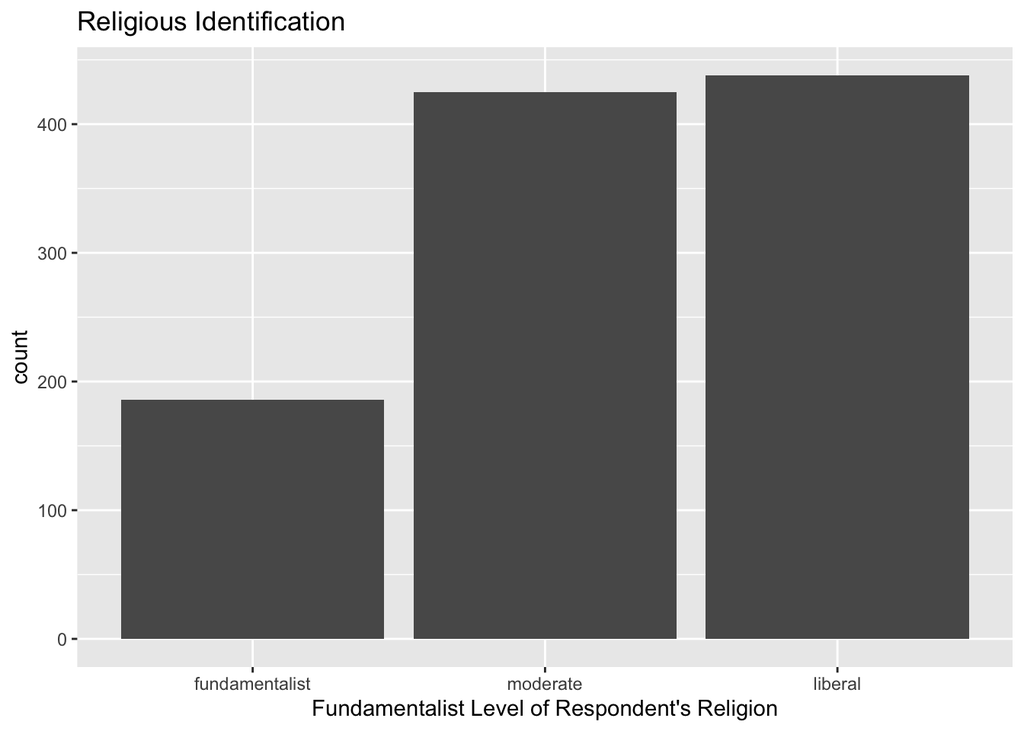

```r
#graphing religious identification in the sample
 ggplot(data=data_no_NA)+
   geom_bar(aes(x=fundamentalistlvl))+
   ggtitle("Religious Identification")+
   xlab("Fundamentalist Level of Respondent's Religion")
```

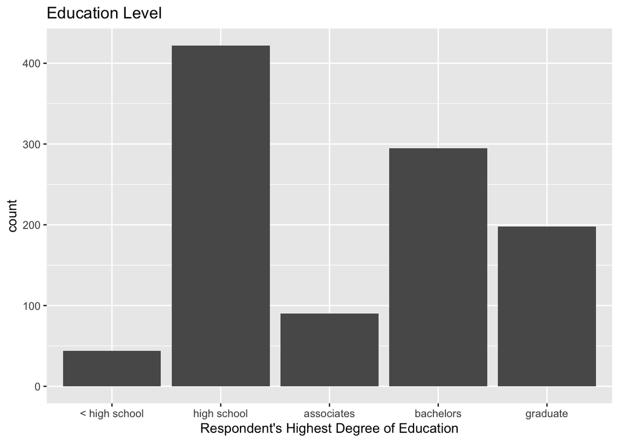

```r
 #graphing education level in the sample
 ggplot(data=data_no_NA)+
   geom_bar(aes(x=highestdegree))+
   ggtitle("Education Level")+
   xlab("Respondent's Highest Degree of Education")
```

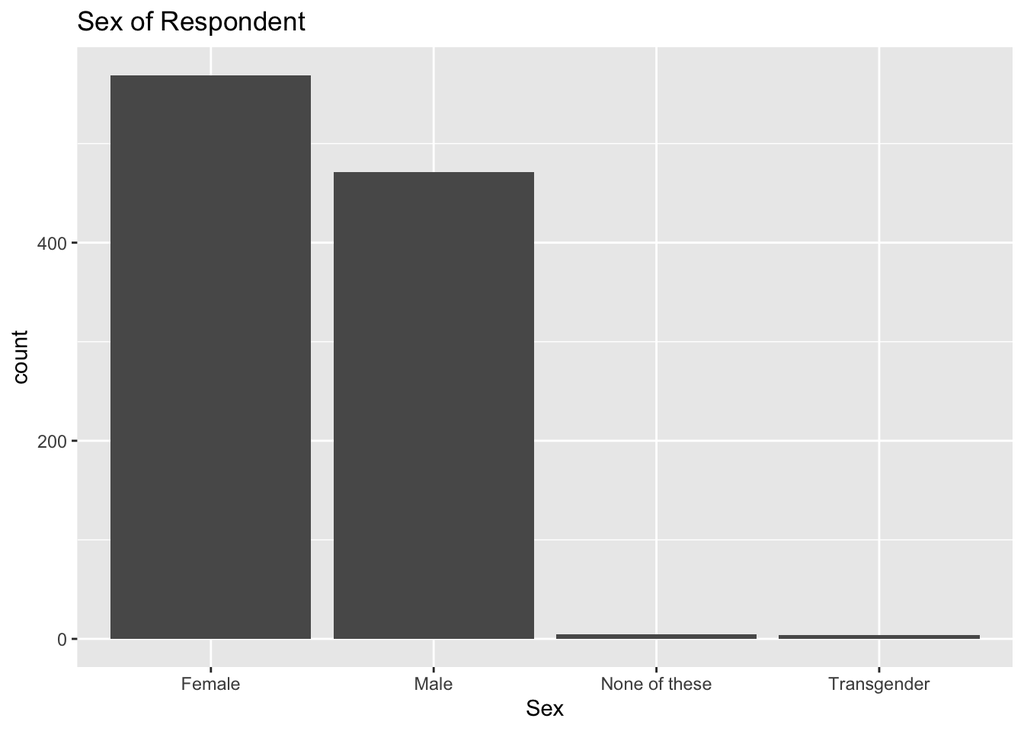

```r
 #graphing sex of respondents in the sample
 ggplot(data=data_no_NA)+
   geom_bar(aes(x=sex1))+
   ggtitle("Sex of Respondent")+
   xlab("Sex")
```

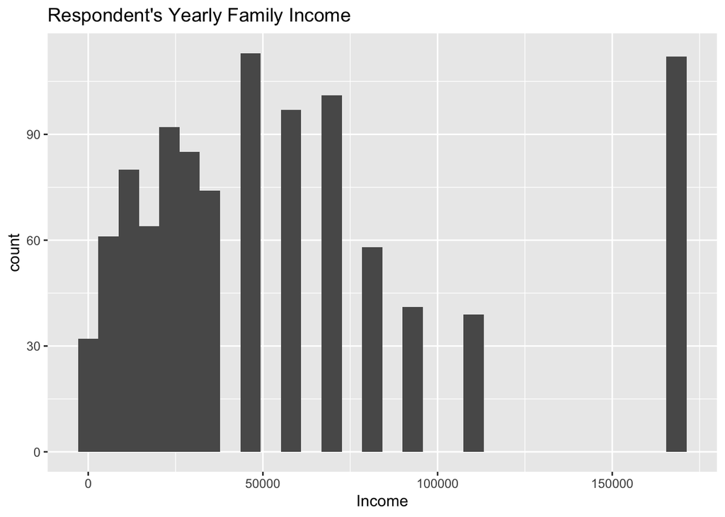

```r
 #graphing income level in the sample
 ggplot(data=data_no_NA)+
   geom_histogram(aes(x=coninc))+
   ggtitle("Respondent's Yearly Family Income")+
   xlab("Income")
```

### Bivariate Graphs

I graphed the relationship between the homophobic variable and each of my demographic variables of interest.

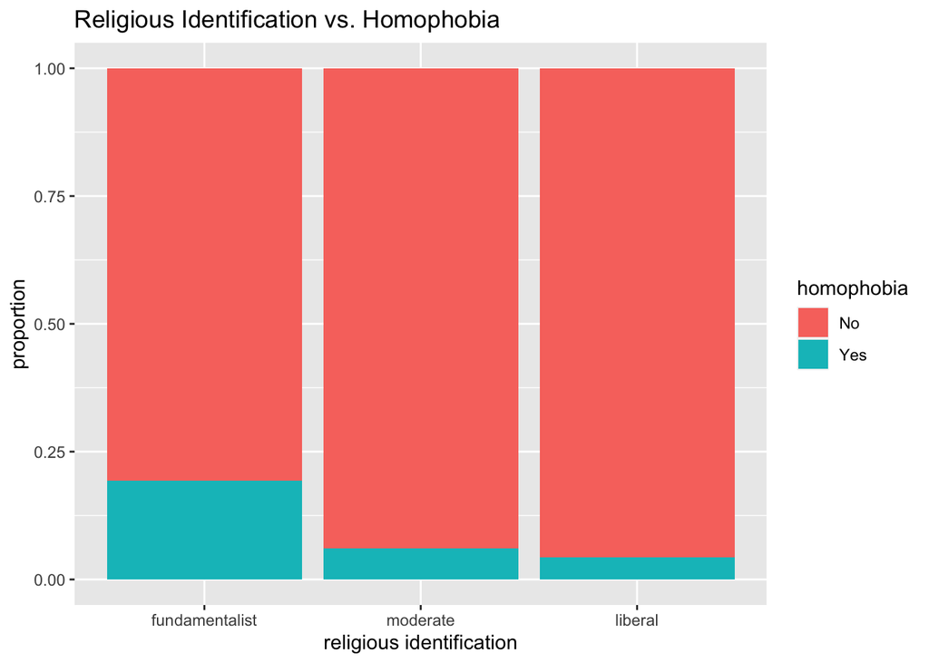

```r
require(ggplot2)
#graph religious identification vs homophobia
 ggplot(data = data_no_NA, aes(x = fundamentalistlvl, fill = homophobia)) +
   geom_bar(position = "fill") + ylab("proportion") +xlab("religious identification") +
   ggtitle("Religious Identification vs. Homophobia")
```

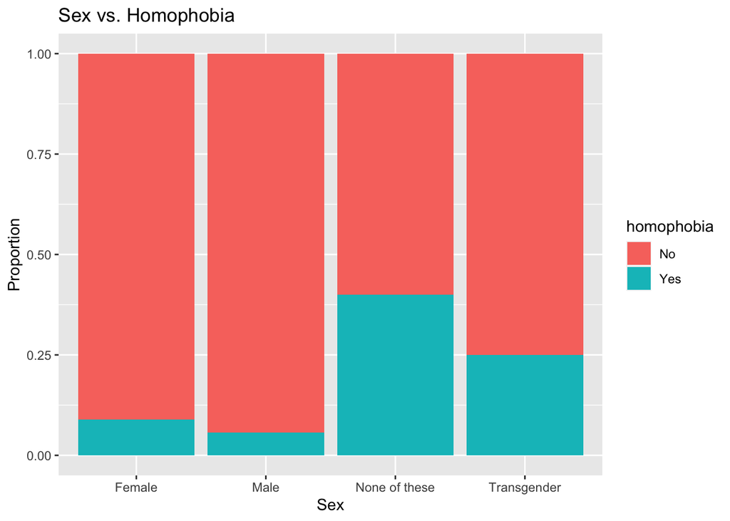

```r
#graph sex vs homophobia
ggplot(data = data_no_NA, aes(x = sex1, fill = homophobia)) +
  geom_bar(position = "fill") + ylab("Proportion") +xlab("Sex")+
  ggtitle("Sex vs. Homophobia")
```

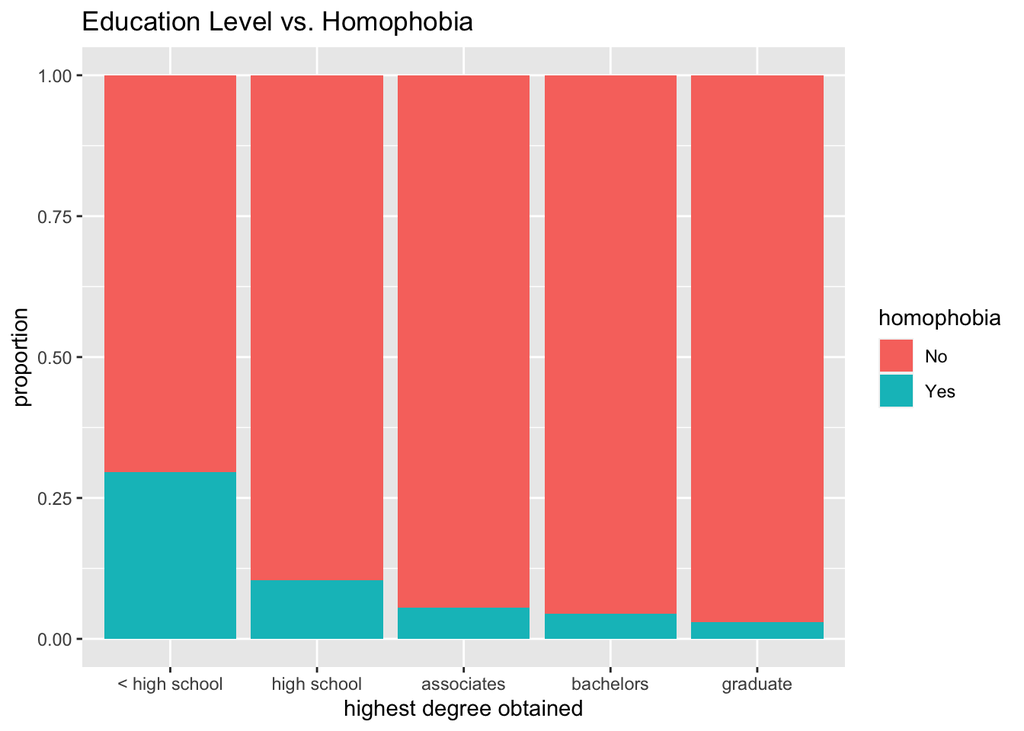

```r
#graph education level vs homophobia
ggplot(data = data_no_NA, aes(x = highestdegree, fill = homophobia)) +
   geom_bar(position = "fill") + ylab("proportion") +xlab("highest degree obtained") +
   ggtitle("Education Level vs. Homophobia")
```

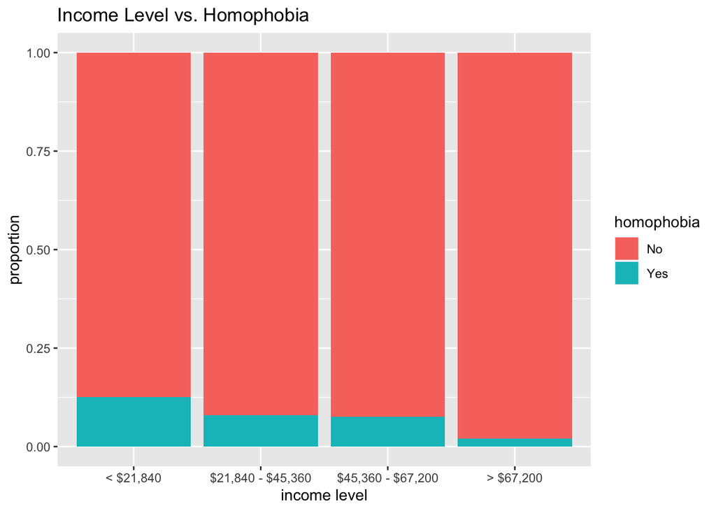

```r
#graph income level vs homophobia
ggplot(data = data_no_NA, aes(x = income, fill = homophobia)) +
   geom_bar(position = "fill") + ylab("proportion") +xlab("income level") +
   ggtitle("Income Level vs. Homophobia")
```

Proportions of respondents indicating homophobic beliefs for each demographic.

```r
#display proportions
tab1 <- table(data_no_NA$homophobia, data_no_NA$fundamentalistlvl)
tab1_colProp <- prop.table(tab1, 2) # column proportions
tab1_colProp
```

```
      fundamentalist   moderate    liberal
  No      0.80645161 0.93882353 0.95662100
  Yes     0.19354839 0.06117647 0.04337900
```

```r
tab2 <- table(data_no_NA$homophobia, data_no_NA$sex1)
tab2_colProp <- prop.table(tab2, 2)
tab2_colProp
```

```
          Female       Male None of these Transgender
  No  0.91036907 0.94267516    0.60000000  0.75000000
  Yes 0.08963093 0.05732484    0.40000000  0.25000000
```

```r
tab3 <- table(data_no_NA$homophobia, data_no_NA$highestdegree)
tab3_colProp <- prop.table(tab3, 2)
tab3_colProp
```

```
      < high school high school associates  bachelors   graduate
  No     0.70454545  0.89573460 0.94444444 0.95593220 0.96969697
  Yes    0.29545455  0.10426540 0.05555556 0.04406780 0.03030303
```

```r
tab4 <- table(data_no_NA$homophobia, data_no_NA$income)
tab4_colProp <- prop.table(tab4, 2)
tab4_colProp
```

```
       < $21,840 $21,840 - $45,360 $45,360 - $67,200  > $67,200
  No  0.87456446        0.92038217        0.92424242 0.98000000
  Yes 0.12543554        0.07961783        0.07575758 0.02000000
```

### Multivariate Graphs

I generated multivariate graphs to get a feel for how fundamentalism interacted with homophobia within different demographic groups.

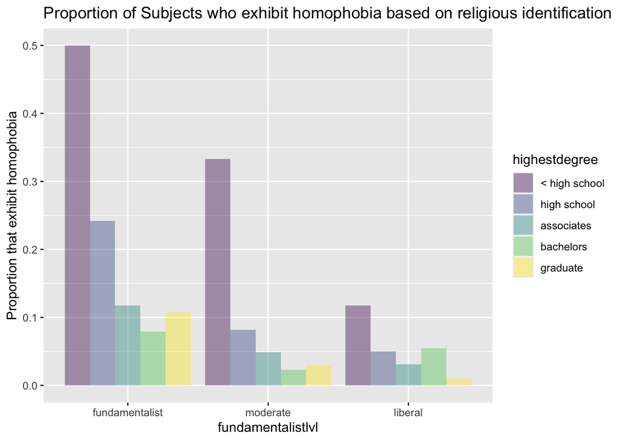

```r
#graphing fundamentalism vs homophobia with degree

ggplot(data=data_no_NA)+
  stat_summary(aes(x=fundamentalistlvl, fill=highestdegree, y=homo),
               fun="mean", geom="bar", position="dodge", alpha=0.4)+
  ylab("Proportion that exhibit homophobia")+
  ggtitle("Proportion of Subjects who exhibit homophobia based on religious identification")
```

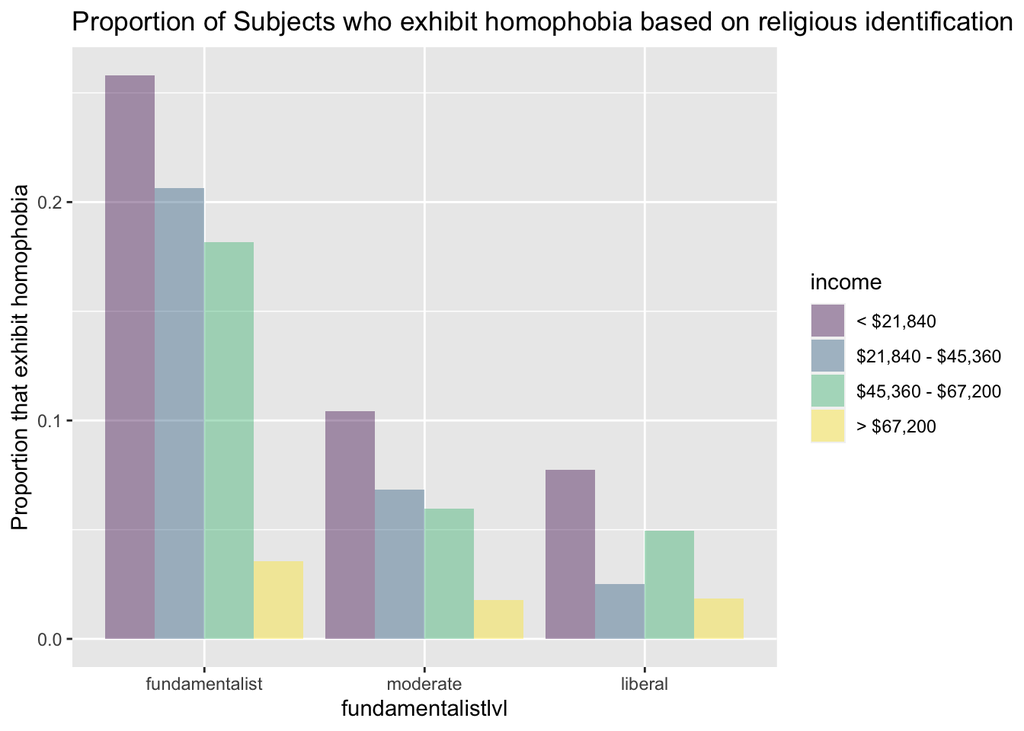

```r
#graphing fundamentalism vs homophobia with income

ggplot(data=data_no_NA)+
  stat_summary(aes(x=fundamentalistlvl, fill=income, y=homo),
               fun="mean", geom="bar", position="dodge", alpha=0.4)+
  ylab("Proportion that exhibit homophobia")+
  ggtitle("Proportion of Subjects who exhibit homophobia based on religious identification")
```

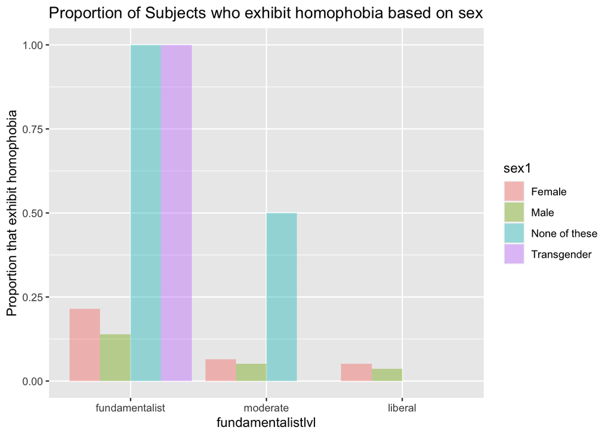

```r
#graphing fundamentalism vs homophobia with sex
ggplot(data=data_no_NA)+
  stat_summary(aes(x=fundamentalistlvl, fill=sex1, y=homo),
               fun="mean", geom="bar", position="dodge", alpha=0.4)+
  ylab("Proportion that exhibit homophobia")+
  ggtitle("Proportion of Subjects who exhibit homophobia based on sex")
```

## Statistical Analysis

### Chi-squared tests

#### Sex vs. Homophobia

Firstly I wanted to explore the statistical significant of the relationship between sex and homophobia using a Pearson’s Chi-squared test. P values were adjusted using the bonferroni post hoc method.

```r
#Performing Chi Squared Analysis (sex vs. Homophobia)

myChi5 <- chisq.test(data_no_NA$homophobia, data_no_NA$sex1)
myChi5
```

```
    Pearson's Chi-squared test

data:  data_no_NA$homophobia and data_no_NA$sex1
X-squared = 12.833, df = 3, p-value = 0.005011
```

```r
Observed_table5<-myChi5$observed

#Post-hoc Test
source("https://raw.githubusercontent.com/PassionDrivenStatistics/R/master/ChiSquarePostHoc.R")
chisq.post.hoc(Observed_table5, popsInRows=FALSE, control="bonferroni")
```

```
Adjusted p-values used the bonferroni method.
```

| comparison | raw.p | adj.p |
| --- | --- | --- |
| Female vs. Male | 0.0581 | 0.3484 |
| Female vs. None of these | 0.0698 | 0.4189 |
| Female vs. Transgender | 0.3172 | 1.0000 |
| Male vs. None of these | 0.0320 | 0.1919 |
| Male vs. Transgender | 0.2164 | 1.0000 |
| None of these vs. Transgender | 1.0000 | 1.0000 |

Since none of the adjusted p values were < 0.05, I concluded that there was **not** a statistically significant relationship between any sex and homophobia. From here onward sex was dropped from the variables of interest.

#### Fundamentalism vs. Homophobia

The next variable I explored was fundamentalist level vs. homophobia. Once again, bonferroni post-hoc method was used to calculate p values.

```r
#Performing Chi Squared Analysis (Fundamentalism vs Homophobia)
myChi <- chisq.test(data_no_NA$homophobia, data_no_NA$fundamentalistlvl)
myChi
```

```
    Pearson's Chi-squared test

data:  data_no_NA$homophobia and data_no_NA$fundamentalistlvl
X-squared = 43.899, df = 2, p-value = 2.933e-10
```

```r
Observed_table<-myChi$observed

#Post-hoc Test
source("https://raw.githubusercontent.com/PassionDrivenStatistics/R/master/ChiSquarePostHoc.R")
chisq.post.hoc(Observed_table, popsInRows=FALSE, control="bonferroni")
```

```
Adjusted p-values used the bonferroni method.
```

| comparison | raw.p | adj.p |
| --- | --- | --- |
| fundamentalist vs. moderate | 0.0000 | 0.0000 |
| fundamentalist vs. liberal | 0.0000 | 0.0000 |
| moderate vs. liberal | 0.2842 | 0.8526 |

Analysis showed that there **was** a statistically significant difference between the levels of homophobia between fundamentalists and liberals as well as between fundamentalists and moderates. However, there **was not** a significant difference between moderates and liberals.

These findings support those of prior literature that indicate religious fundamentalism as a predictor of homophobia.

#### Degree vs Homophobia

Next I tested the relationship between the highest degree held by respondent and presence of homophobic beliefs.

```r
#Performing Chi Squared Analysis (Degree vs. Homophobia)

myChi2 <- chisq.test(data_no_NA$homophobia, data_no_NA$highestdegree)
myChi2
```

```
    Pearson's Chi-squared test

data:  data_no_NA$homophobia and data_no_NA$highestdegree
X-squared = 45.001, df = 4, p-value = 3.973e-09
```

```r
Observed_table2<-myChi2$observed

#Post-hoc Test
source("https://raw.githubusercontent.com/PassionDrivenStatistics/R/master/ChiSquarePostHoc.R")
chisq.post.hoc(Observed_table2, popsInRows=FALSE, control="bonferroni")
```

```
Adjusted p-values used the bonferroni method.
```

| comparison | raw.p | adj.p |
| --- | --- | --- |
| < high school vs. high school | 0.0010 | 0.0096 |
| < high school vs. associates | 0.0003 | 0.0028 |
| < high school vs. bachelors | 0.0000 | 0.0000 |
| < high school vs. graduate | 0.0000 | 0.0000 |
| high school vs. associates | 0.1724 | 1.0000 |
| high school vs. bachelors | 0.0031 | 0.0311 |
| high school vs. graduate | 0.0013 | 0.0131 |
| associates vs. bachelors | 0.5816 | 1.0000 |
| associates vs. graduate | 0.3279 | 1.0000 |
| bachelors vs. graduate | 0.4845 | 1.0000 |

Results showed that most levels of education were statistically different (p < 0.05) from each other in presence of homophobic beliefs. However, the associates category was not different from any other category except < high school and bachelors and graduate were not statistically different from each other.

Interestingly, the < high school group was statistically more homophobic than every other education group.

### Logistic Analysis

I then moved to logistic analysis to model the relationship between variables that were shown to be correlated.

#### Fundamentalism vs Homophobia

Firstly, I was interested in modeling the relationship between fundamentalism and homophobia.

##### Logistic Regression

```r
#Ensuring that fundamentalistlvl and highestdegree are string type before logistic analysis
data_no_NA$fundamentalistlvl<- as.character(data_no_NA$fundamentalistlvl)
data_no_NA$highestdegree<- as.character(data_no_NA$highestdegree)

#Performing Logistic Regression (Fundamentalism vs. Homophobia)
my.logreg <- glm(homo ~ fundamentalistlvl, data = data_no_NA, family = "binomial")
summary(my.logreg)  # for p-values
```

```
Call:
glm(formula = homo ~ fundamentalistlvl, family = "binomial",
    data = data_no_NA)

Coefficients:
                          Estimate Std. Error z value Pr(>|z|)
(Intercept)                -1.4271     0.1856  -7.690 1.48e-14 ***
fundamentalistlvlliberal   -1.6663     0.2991  -5.572 2.52e-08 ***
fundamentalistlvlmoderate  -1.3037     0.2746  -4.748 2.06e-06 ***
---
Signif. codes:  0 '***' 0.001 '**' 0.01 '*' 0.05 '.' 0.1 ' ' 1

(Dispersion parameter for binomial family taken to be 1)

    Null deviance: 570.48  on 1048  degrees of freedom
Residual deviance: 534.84  on 1046  degrees of freedom
AIC: 540.84

Number of Fisher Scoring iterations: 5
```

Liberals and Moderates show a statistically different response level of homophobia compared to Fundamentalists.

##### Odds Ratios

```r
exp(my.logreg$coefficients)  # for odds ratios
```

```
              (Intercept)  fundamentalistlvlliberal fundamentalistlvlmoderate
                0.2400000                 0.1889419                 0.2715121
```

```r
exp(confint(my.logreg))  # for confidence intervals on the odds ratios
```

```
                              2.5 %    97.5 %
(Intercept)               0.1643812 0.3410242
fundamentalistlvlliberal  0.1032599 0.3356810
fundamentalistlvlmoderate 0.1571398 0.4631740
```

The odds ratios show that the odds of those who identify as moderate being homophobic are 73% lower than those who identify as fundamentalist. Those who identify as liberal have odds 81% lower than fundamentalists. Confidence intervals do not include the null and show a moderate level of precision.

##### Graphing this Relationship

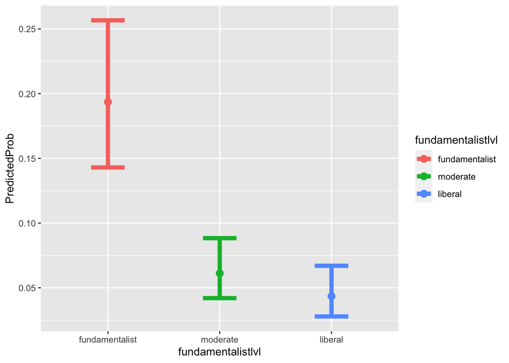

```r
#graph logistic regression

graphdata<-expand.grid(fundamentalistlvl=c("fundamentalist","moderate","liberal"))

graphdata<-cbind(graphdata, predict(my.logreg, newdata=graphdata, type="link", se=TRUE))

graphdata<-cbind(graphdata, PredictedProb=plogis(graphdata$fit),
                 LL=plogis(graphdata$fit-1.96*graphdata$se.fit),
                 UL=plogis(graphdata$fit+1.96*graphdata$se.fit))

#Plotting relationship between fundamentalism and homophobia
ggplot(data=graphdata)+
  geom_errorbar(aes(x=fundamentalistlvl, y=PredictedProb, ymin=LL, color=fundamentalistlvl, ymax=UL),width=0.3, size=2)+
  geom_point(aes(x=fundamentalistlvl, y=PredictedProb, color=fundamentalistlvl), size=3)
```

#### Fundamentalism vs. Homophobia with respect to Degree

Next, I wanted to model this same relationship but now taking into account the highest degree of the respondent.

```r
#Performing Logistic Regression (Fundamentlism vs. Homophobia) wrt degree
my.logreg2<-glm(homo~fundamentalistlvl+highestdegree, family="binomial", data=data_no_NA)
summary(my.logreg2)
```

```
Call:
glm(formula = homo ~ fundamentalistlvl + highestdegree, family = "binomial",
    data = data_no_NA)

Coefficients:
                          Estimate Std. Error z value Pr(>|z|)
(Intercept)                0.07097    0.38152   0.186 0.852423
fundamentalistlvlliberal  -1.55138    0.30698  -5.054 4.33e-07 ***
fundamentalistlvlmoderate -1.21056    0.28203  -4.292 1.77e-05 ***
highestdegreeassociates   -1.95890    0.58175  -3.367 0.000759 ***
highestdegreebachelors    -2.07919    0.45008  -4.620 3.84e-06 ***
highestdegreegraduate     -2.47978    0.54302  -4.567 4.96e-06 ***
highestdegreehigh school  -1.29081    0.38378  -3.363 0.000770 ***
---
Signif. codes:  0 '***' 0.001 '**' 0.01 '*' 0.05 '.' 0.1 ' ' 1

(Dispersion parameter for binomial family taken to be 1)

    Null deviance: 570.48  on 1048  degrees of freedom
Residual deviance: 505.15  on 1042  degrees of freedom
AIC: 519.15

Number of Fisher Scoring iterations: 6
```

When accounting for difference in education level, moderates and liberals still show significantly different levels of homophobia than fundamentalists. Additionally, those with high school degrees, associates, bachelors, and graduate degrees show statistically different levels of homophobia than those without high school degrees.

##### Odds Ratios

```r
exp(my.logreg2$coefficients)  # for odds ratios
```

```
              (Intercept)  fundamentalistlvlliberal fundamentalistlvlmoderate
               1.07355197                0.21195607                0.29803018
  highestdegreeassociates    highestdegreebachelors     highestdegreegraduate
               0.14101357                0.12503202                0.08376126
 highestdegreehigh school
               0.27504847
```

```r
exp(confint(my.logreg2)) # for confidence intervals
```

```
                               2.5 %    97.5 %
(Intercept)               0.49780181 2.2458172
fundamentalistlvlliberal  0.11414160 0.3826224
fundamentalistlvlmoderate 0.17009454 0.5161132
highestdegreeassociates   0.04125158 0.4198621
highestdegreebachelors    0.05128319 0.3034580
highestdegreegraduate     0.02702925 0.2344821
highestdegreehigh school  0.13147332 0.5977634
```

Odds of being homophobic compared to those without high school diploma controlling for religious identification: High school grads: 73% lower, Associates: 86% lower, Bachelors: 88% lower, Graduate: 92% lower.

Confidence intervals do not include null, reinforcing the precision of these findings. Liberal and moderate confidene intervals overlap significantly which shows that the differences between these categories are not great. High school, Associates, Bachelors, and Graduate all have overlapping confidence intervals.

##### Graphing this Relationship

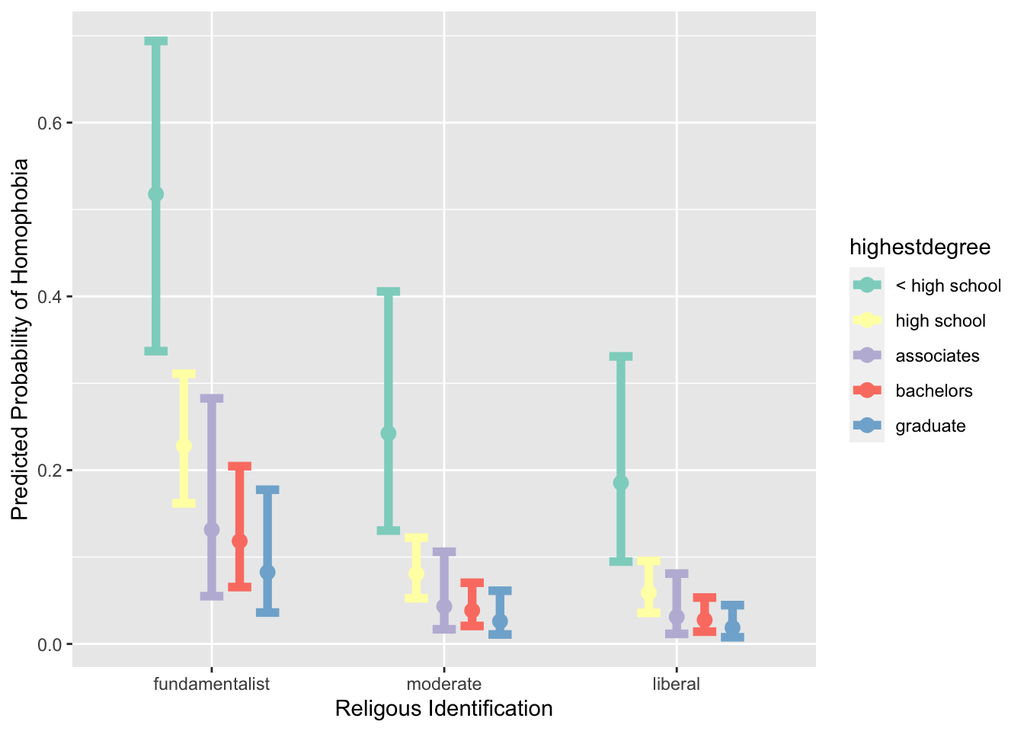

```r
#graphing
graphdata2<-expand.grid(fundamentalistlvl=c("fundamentalist","moderate","liberal"),
                        highestdegree=c("< high school","high school","associates", "bachelors", "graduate"))

graphdata2<-cbind(graphdata2, predict(my.logreg2, newdata=graphdata2, type="link", se=TRUE))

graphdata2<-cbind(graphdata2, PredictedProb=plogis(graphdata2$fit),
                  LL=plogis(graphdata2$fit-1.96*graphdata2$se.fit),
                  UL=plogis(graphdata2$fit+1.96*graphdata2$se.fit))
graphdata2$highestdegree=as.factor(graphdata2$highestdegree)
seep=ggplot(data=graphdata2)+
  geom_errorbar(aes(x=fundamentalistlvl, y=PredictedProb, color=highestdegree, ymin=LL, ymax=UL),width=0.5, size=2, position=position_dodge(width=0.6))+
  geom_point(aes(x=fundamentalistlvl, y=PredictedProb, color=highestdegree,group=as.factor(highestdegree)), size=3, position=position_dodge(width=0.6))+
  scale_fill_manual(values=wes_palette(n=5, name="Moonrise3"))+
  xlab("Religous Identification")+
  ylab("Predicted Probability of Homophobia")
seep+scale_color_brewer(palette="Set3")
```

The general trend of the data is that as education level increases, homophobia decreases although most statistical significance lies between those who do not have a high school education and every other category.

#### Fundamentalism vs. Homophobia with respect to Income

##### Logistic Regression

```r
#Performing Logistic Regression (Fundamentlism vs. Homophobia) wrt income
my.logreg3<-glm(homo~fundamentalistlvl+income, family="binomial", data=data_no_NA)
summary(my.logreg3)
```

```
Call:
glm(formula = homo ~ fundamentalistlvl + income, family = "binomial",
    data = data_no_NA)

Coefficients:
                          Estimate Std. Error z value Pr(>|z|)
(Intercept)                -1.6960     0.2132  -7.954 1.81e-15 ***
fundamentalistlvlliberal   -1.6007     0.3025  -5.292 1.21e-07 ***
fundamentalistlvlmoderate  -1.1729     0.2787  -4.209 2.57e-05 ***
income.L                   -1.2204     0.3382  -3.609 0.000308 ***
income.Q                   -0.3904     0.3000  -1.301 0.193182
income.C                   -0.4153     0.2568  -1.617 0.105817
---
Signif. codes:  0 '***' 0.001 '**' 0.01 '*' 0.05 '.' 0.1 ' ' 1

(Dispersion parameter for binomial family taken to be 1)

    Null deviance: 570.48  on 1048  degrees of freedom
Residual deviance: 515.13  on 1043  degrees of freedom
AIC: 527.13

Number of Fisher Scoring iterations: 6
```

When controlling for income level, liberals and moderates still show significantly different levels of homophobia than fundamentalists. The highest and lowest income bracket are statistically different from each other in homophobic response.

##### Odds Ratios

```r
exp(my.logreg3$coefficients)
```

```
              (Intercept)  fundamentalistlvlliberal fundamentalistlvlmoderate
                0.1834114                 0.2017459                 0.3094808
                 income.L                  income.Q                  income.C
                0.2951016                 0.6768118                 0.6601390
```

```r
exp(confint(my.logreg3))
```

```
                              2.5 %    97.5 %
(Intercept)               0.1181674 0.2735472
fundamentalistlvlliberal  0.1095625 0.3608702
fundamentalistlvlmoderate 0.1777883 0.5323488
income.L                  0.1402187 0.5420825
income.Q                  0.3607117 1.1909513
income.C                  0.3993007 1.1002405
```

Odds of being homophobic accounting for income level, compared to fundamentalists: moderates: 69% lower, liberals: 80% lower. Once again, confidence intervals showed that moderates and liberals are not very different.

##### Graphing this Relationship

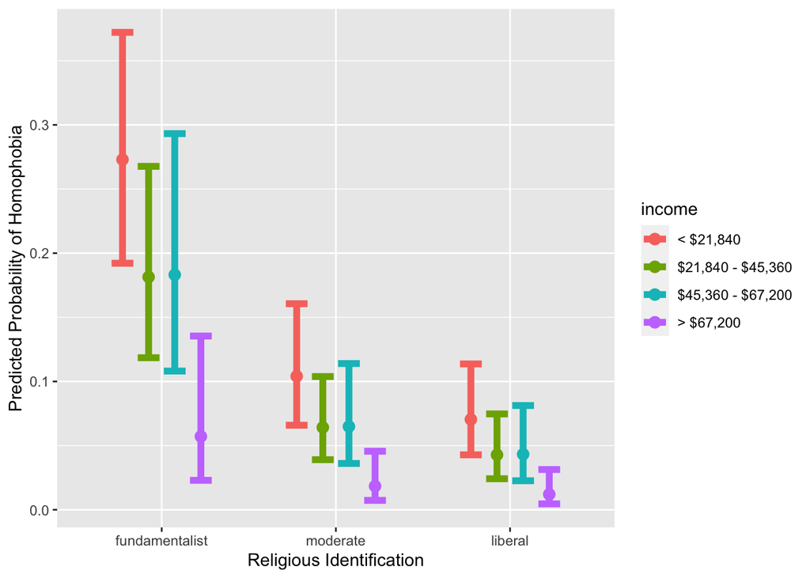

```r
#graphing
graphdata3<-expand.grid(fundamentalistlvl=c("fundamentalist","moderate","liberal"),
                        income=c("< $21,840","$21,840 - $45,360","$45,360 - $67,200","> $67,200"))

graphdata3<-cbind(graphdata3, predict(my.logreg3, newdata=graphdata3, type="link", se=TRUE))

graphdata3<-cbind(graphdata3, PredictedProb=plogis(graphdata3$fit),
                  LL=plogis(graphdata3$fit-1.96*graphdata3$se.fit),
                  UL=plogis(graphdata3$fit+1.96*graphdata3$se.fit))

graphdata3$income=as.factor(graphdata3$income)

ggplot(data=graphdata3)+
  geom_errorbar(aes(x=fundamentalistlvl, y=PredictedProb, color=income, ymin=LL, ymax=UL),width=0.5, size=2, position=position_dodge(width=0.6))+
  geom_point(aes(x=fundamentalistlvl, y=PredictedProb, color=as.factor(income),group=as.factor(income)), size=3, position=position_dodge(width=0.6))+
  xlab("Religious Identification")+
  ylab("Predicted Probability of Homophobia")
```

The general trend of the data was that as income increased, homophobia decreased with the differences being most pronounced in the fundamentalist category.

## Discussion

In agreement with prior research, fundamentalism is predictive of homophobia regardless of education level or class. Within this analysis, class and education level respond similarly in relation to homophobia, supporting the hypothesis that these variables are interrelated.

More research is needed to better understand what characteristics of fundamentalist religious beliefs are associated with homophobia. Addressing key characteristics of these beliefs could be important for eliminating these bigoted values.